# chapter3.rmd

Alex Suomalainen

12 11 2020

# Regression and model validation

## Analyze

reading the data into r

```r
alc <- read.csv('alc.csv', TRUE, ",")
```

cheking the names of the variables

```r
str(alc)
```

```
## 'data.frame':    382 obs. of  36 variables:
##  $ X         : int  1 2 3 4 5 6 7 8 9 10 ...
##  $ school    : chr  "GP" "GP" "GP" "GP" ...
##  $ sex       : chr  "F" "F" "F" "F" ...
##  $ age       : int  18 17 15 15 16 16 16 17 15 15 ...
##  $ address   : chr  "U" "U" "U" "U" ...
##  $ famsize   : chr  "GT3" "GT3" "LE3" "GT3" ...
##  $ Pstatus   : chr  "A" "T" "T" "T" ...
##  $ Medu      : int  4 1 1 4 3 4 2 4 3 3 ...
##  $ Fedu      : int  4 1 1 2 3 3 2 4 2 4 ...
##  $ Mjob      : chr  "at_home" "at_home" "at_home" "health" ...
##  $ Fjob      : chr  "teacher" "other" "other" "services" ...
##  $ reason    : chr  "course" "course" "other" "home" ...
##  $ nursery   : chr  "yes" "no" "yes" "yes" ...
##  $ internet  : chr  "no" "yes" "yes" "yes" ...
```

[output cut: 22 more lines]

assessing libraries

```r
library(tidyverse); library(tidyr); library(ggplot2); library(dplyr)
```

first I look at age and alcohol comsumption

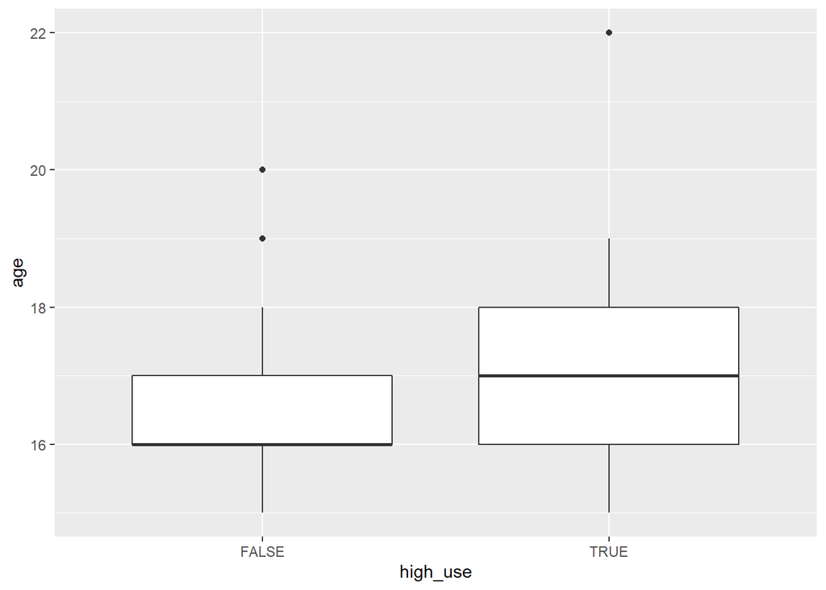

```r
ggplot(alc, aes(x = high_use , y = age  )) +
  geom_boxplot()
```

High usage of alcohol seems to rise as age rises.

Next lets take a look at go out time

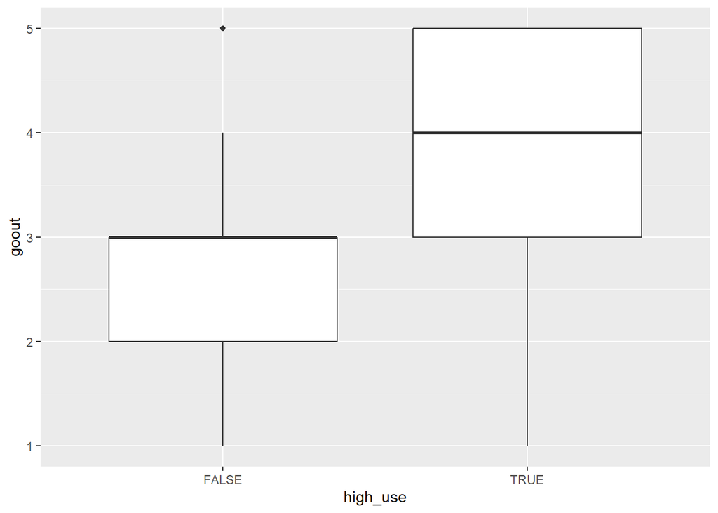

```r
ggplot(alc, aes(x = high_use, y = goout  )) +
  geom_boxplot()
```

Alcohol usage seems to increase as go out time increases, which makes sense.

Next up, studytime vs. alcohol consumption

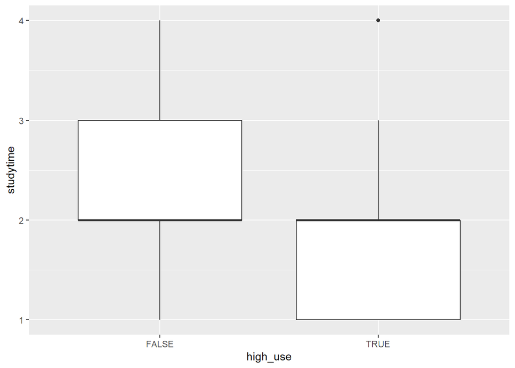

```r
ggplot(alc, aes(x = high_use, y = studytime  )) +
  geom_boxplot()
```

With more study time there is less high alcocol usage.

Last up, traveltime. This should be interesting

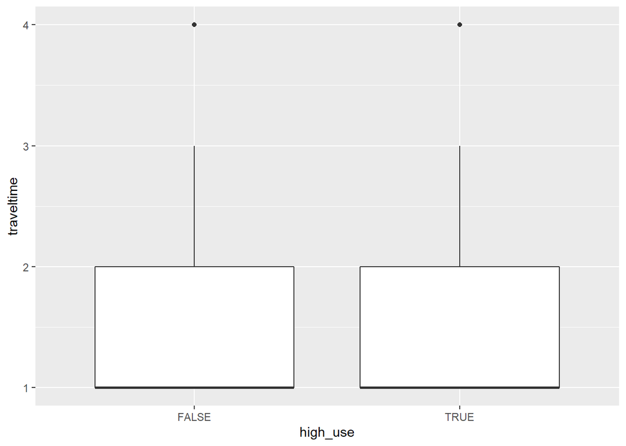

```r
ggplot(alc, aes(x = high_use, y = traveltime  )) +
  geom_boxplot()
```

There seems to be no correlation with traveltime and high alcohol usage

## Logistic regression

find the model with glm()

```r
m <- glm( high_use ~ alc$age + alc$goout + alc$studytime + alc$traveltime, data = alc, family = "binomial" )
```

summarising

```r
summary(m)
```

```
##
## Call:
## glm(formula = high_use ~ alc$age + alc$goout + alc$studytime +
##     alc$traveltime, family = "binomial", data = alc)
##
## Deviance Residuals:
##     Min       1Q   Median       3Q      Max
## -1.5430  -0.7827  -0.5205   0.8918   2.5154
##
## Coefficients:
##                Estimate Std. Error z value Pr(>|z|)
## (Intercept)     -4.4550     1.8291  -2.436 0.014865 *
## alc$age          0.1111     0.1089   1.020 0.307783
## alc$goout        0.7271     0.1179   6.166 7.02e-10 ***
## alc$studytime   -0.5773     0.1657  -3.484 0.000494 ***
## alc$traveltime   0.3367     0.1749   1.925 0.054271 .
## ---
## Signif. codes:  0 '***' 0.001 '**' 0.01 '*' 0.05 '.' 0.1 ' ' 1
##
## (Dispersion parameter for binomial family taken to be 1)
##
##     Null deviance: 465.68  on 381  degrees of freedom
## Residual deviance: 395.60  on 377  degrees of freedom
## AIC: 405.6
##
## Number of Fisher Scoring iterations: 4
```

All variables except age have a relatively low p-value suggesting that there is a relationship betweed them and high alcohol comsumption

Lets compute the odds ratios

```r
OR <- coef(m) %>% exp
```

and confidence intervals

```r
CI <- confint(m) %>% exp
```

Then lets print out the odds ratios with the intervals

```r
cbind(OR, CI)
```

```
##                        OR        2.5 %    97.5 %
## (Intercept)    0.01162006 0.0003030623 0.4014593
## alc$age        1.11745223 0.9034948833 1.3861881
## alc$goout      2.06914207 1.6517703458 2.6253545
## alc$studytime  0.56142689 0.4014579153 0.7701737
## alc$traveltime 1.40030161 0.9937673028 1.9784019
```

It seems that most likely when go out time increases, high alcohol consumption increases.  
It also seems like the more you study the less likely it is that you comsume a lot of alcohol. These were the correct hypotheses.

I don’t see a strong correlation with age and high alcohol usage, since the OR is only 1.12.

Thats all I’m able to do. This math stuff is all new to me so this could be totally wrong.